# Some latent variable simulations

- Show All Code
- Hide All Code
- View Source

This post looks at the relationship between continuous predictors, latent variables, and predicted ordinal ratings.

R

Published

July 22, 2024

I found myself second guessing myself about the relationship between thresholds, a predictor variable $x$, and a latent variable $Y*$ in cumulative link models. So, I ran some simulations to double check that thresholds partition values of $Y*$, but this doesn’t translate to partitioning values of $x$. A lot of the things here are stated formally already in McCullagh’s 1980 paper and Agresti’s 2010 textbook, so the simulations are just to convince myself.

## Setup

```r
library(ordinal)
library(tidyverse)

plot_theme <-
  list(
    scale_color_brewer(palette = "Dark2"),
    theme_bw(base_size = 16),
    theme(panel.grid = element_line(linewidth = .3))
  )
```

Helpers to work with threshold values.

```r
# Get probabilities for k ratings given k-1 threshold values
get_rating_probabilities <- function(thetas) {
  c(plogis(thetas[1]), diff(c(plogis(thetas), 1)))

}

# Multinomial sampling given threshold allocations
sample_ratings <- function(x, thresholds, size = 50, B = 1.25) {
  probs <- get_rating_probabilities(thresholds - B*x)
  rmultinom(1, size, probs)[,1]
}
```

Set up some hyperparameters for the simulations, we’ll use a single continuous variable `x`.

```r
xvals <- seq(-4,4, by = .01)
thetas <- c(-1.5,0,.9)
n_points <- 400
```

## The simulations

Below we simulate a bunch of ratings at each value of `x`, then wrangle that into a long dataframe of rating observations.

```r
set.seed(111)

# Simulate n_points observations at each value of x
raw_data <-
  data.frame(
    x = rep(xvals, each = 4),
    rating = ordered(rep(1:4, times = length(xvals))),
    response_count =
      c(
        lapply(xvals, \(x) sample_ratings(x, thetas, size = n_points)),
        recursive = TRUE
      )
  )

# Convert counts to individual observations
response_data <-
  raw_data |>
  reframe(.by = c('x', 'rating', 'response_count'),
          response = seq_len(response_count[1]))
```

Below we can see what the proportion of ratings are for each value of `x`.

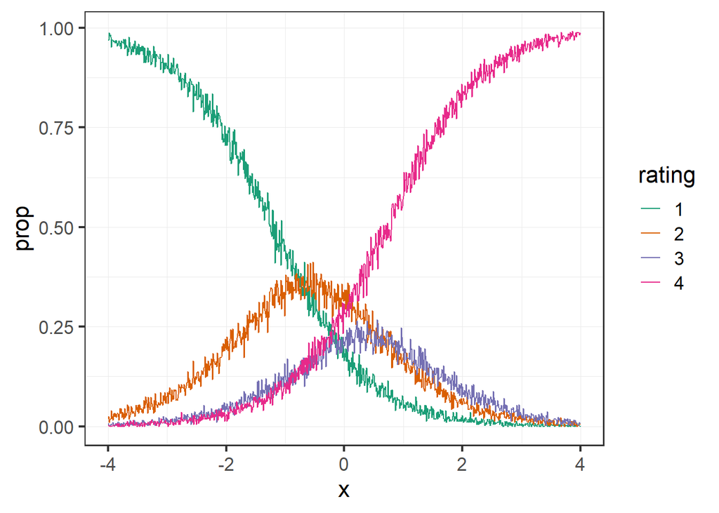

```r
raw_data |>
  mutate(prop = response_count / n_points) |>
  ggplot(aes(x = x, y = prop, color = rating)) +
  geom_line() +
  plot_theme
```

Let’s model this using a simple clm.

```r
simulated_mdl <- clm(rating ~ x, data = response_data)
```

We can extract the predictions for each value of `x`. There are different predictions we can get:

- The predicted probability of each rating given `x`
- The predicted rating given `x`
- The predicted cumulative probabilities up to each rating category given `x`
- The log odds of the cumulative probabilities up to each rating category given `x` (i.e., the linear combination of predictors given the thresholds, coefficient estimates, and `x`)

I’m only going to focus on the first three, as the linear predictors are directly related to the cumulative probabilities via the link function.

```r
prob_preds <-
  cbind(x = xvals,
        predict(simulated_mdl, data.frame(x = xvals), type = "prob")$fit)
rating_preds <-
  cbind(x = xvals,
        predict(simulated_mdl, data.frame(x = xvals), type = "class")$fit) |>
  as.data.frame()
cumprob_preds <-
  cbind(x = xvals,
        predict(simulated_mdl, data.frame(x = xvals), type = "cum.prob")$cprob1)
```

Wrangle the more complicated ones into dataframes:

```r
probs_df <-
  prob_preds |>
  as.data.frame() |>
  pivot_longer(cols = 2:5,
               names_to = "rating",
               values_to = "prob")

cumprob_df <-
  cumprob_preds |>
  as.data.frame() |>
  pivot_longer(cols = 2:5,
               names_to = "rating",
               values_to = "prob")
```

### Simulation results

We can plot the predicted probabilities of each rating along with what the predicted rating is for each value of `x`. Note that the predicted rating $Y$ is going to be the rating that has the highest probability. Here are the predictions; the discrete rating is shown by a black line.

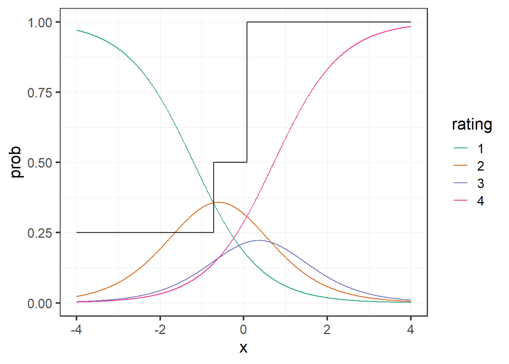

```r
probs_df |>
  ggplot(aes(x = x, y = prob, group = rating, color = rating)) +
  geom_line() +
  geom_line(data = rating_preds,
            aes(x = x, y = as.numeric(V2)/4),
            color = "black",
            inherit.aes = FALSE)+
  plot_theme
```

Here are the predictions superimposed on top of our empirical proportions; good fit! (we’d be in trouble if it wasn’t)

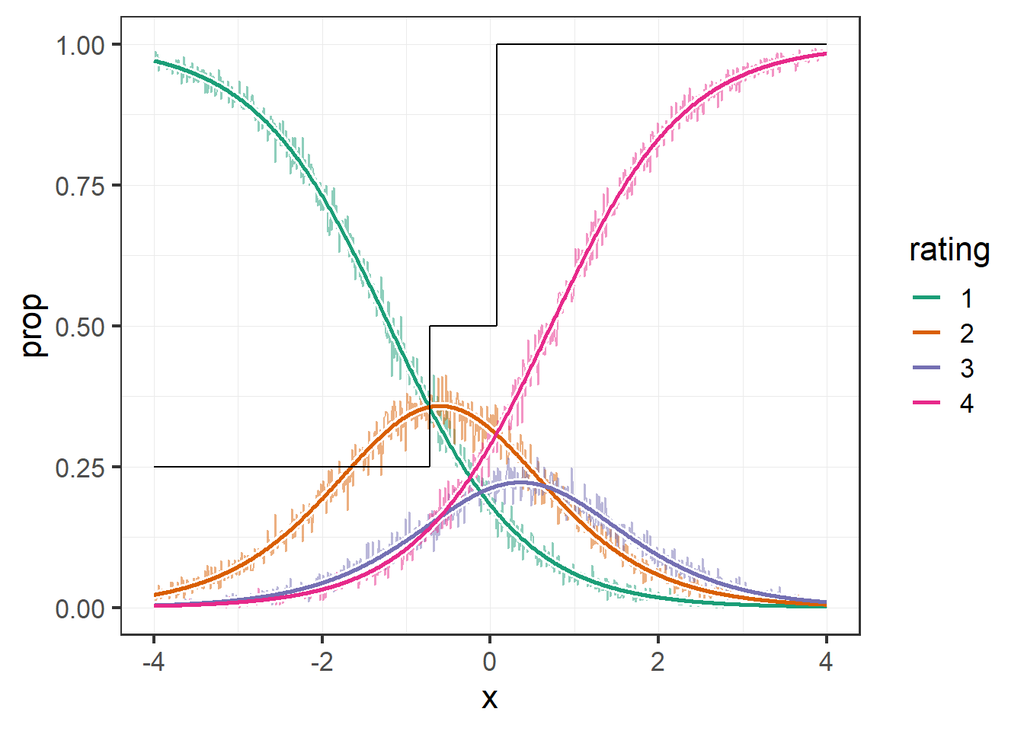

```r
raw_data |>
  mutate(prop = response_count / n_points) |>
  ggplot(aes(x = x, y = prop, color = rating, group = rating)) +
  geom_line(alpha = .5) +
  geom_line(data = probs_df,
            aes(y = prob),
            color = 'white',
            linewidth = 2)+
  geom_line(data = probs_df,
            aes(y = prob),
            linewidth = 1)+
  geom_line(data = rating_preds,
            aes(x = x, y = as.numeric(V2)/4),
            color = "black",
            inherit.aes = FALSE)+
  plot_theme
```

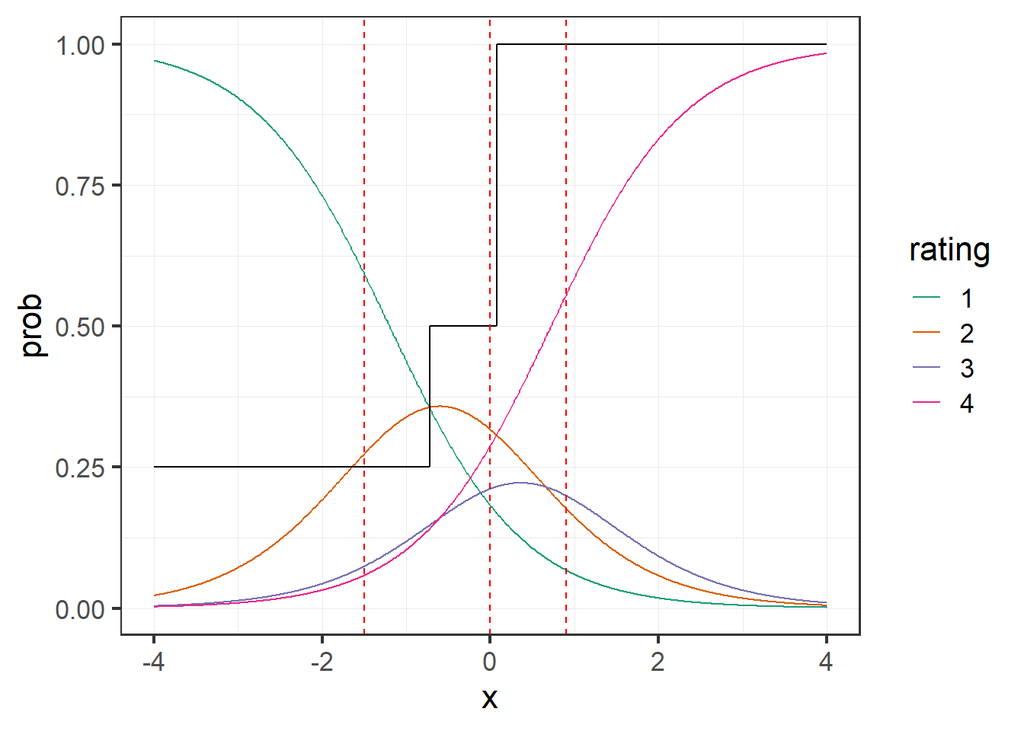

```r
plot_thetas <- function(scale = FALSE,
                        color = 'red',
                        linetype = 'dashed',
                        model = simulated_mdl) {
  thetas <- model$Theta

  if (scale)
    thetas <- thetas / model$coefficients['x']

  lapply(
    thetas,
    \(t) geom_vline(xintercept = t, color = color, linetype = linetype)
  )
}

probs_df |>
  ggplot(aes(x = x, y = prob, group = rating, color = rating)) +
  geom_line() +
  geom_line(data = rating_preds,
            aes(x = x, y = as.numeric(V2)/4),
            color = "black",
            inherit.aes = FALSE)+
  plot_thetas() +
  plot_theme
```

Rather, the thresholds are related to where the cumulative probabilities up to a given rating category is 50%. We can work this out analytically. Assuming a logit link function, 50% corresponds to a logit of 0.

$$\begin{align*}
\text{logit}[P(y\leq j)]&=\theta_j - \beta*x \\
0 &= \theta_j - \beta*x \\
x &= \frac{\theta_j}{\beta}
\end{align*}$$

Again, this is not the value of `x` at which a specific rating is predicted, but the value of `x` at which the cumulative probability given a particular rating category $j$ is equal to 50%. Below, the threshold values are plotted in gray dotted lines and the transformed values for finding where the cumulative probabilities are equal to 50% are plotted in red.

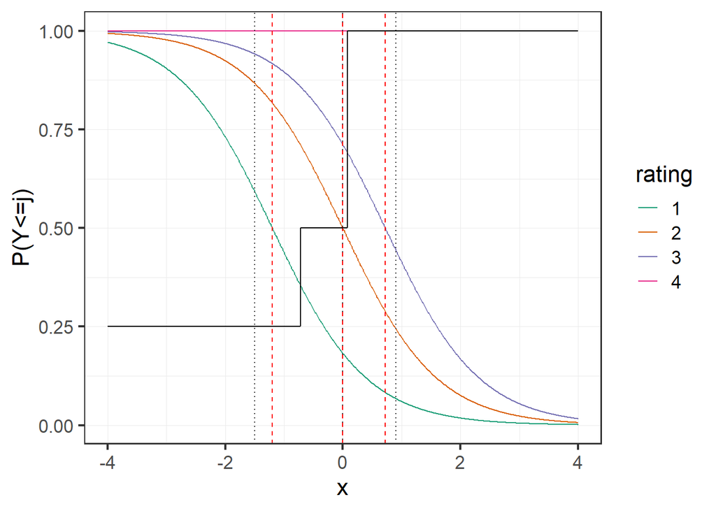

```r
cumprob_df |>
  ggplot(aes(x = x, y = prob, group = rating, color = rating)) +
  geom_line() +
  plot_thetas(scale=FALSE, "gray20", "dotted") +
  plot_thetas(scale=TRUE) +
  geom_line(data = rating_preds,
            aes(x = x, y = as.numeric(V2)/4),
            color = "black",
            inherit.aes = FALSE) +
  plot_theme +
  ylab("P(Y<=j)")
```

Taking the first curve as an example, we can say that at (just past) the first transformed threshold, the probability of a 1 is less than the probability of a rating higher than 1 (=2,3,4). But, the individual probability of a 1 can be higher than the individual probabilities of a 2, 3, or 4 response. Somewhat relatedly, for the third curve at the third transformed threshold, we can see that the probability of a 1, 2, or 3 response becomes less likely than a 4 response. But by the time we subtract out the likelihood of a 1 or 2, then the likelihood of a 1, we find that the individual probability of a 3 is never higher than the individual probabilities of a 1, 2, or 4 rating. Hence, we never predict a rating of 3 for any value of `x`.

Where did all our 3s go?? Because $Y=3$ is never the *most likely* rating, it isn’t predicted given values of `x`. If we’re supposed to get a value of 3 whenever a value of $Y*$ falls between $\theta_{2|3}$ and $\theta_{3|4}$, then how is `x` related to $Y*$? Here, `x` affects the distribution of $Y*$ values via shifting its location. In other words, $Y*$ is taken to vary about a location $\eta$, which in the context of our model depends on `x` via $\beta x$, i.e., $\eta(x)=\beta x$.

How is $Y*$ distributed? Given our link function, it’ll be a logistic distribution. So, we can sample values of $Y*$ from a logistic distribution at different values of $x$, then use our thresholds to categorize the sampled values of $Y*$ and obtain ratings $Y$. By doing so, we can reintroduce some 3s, which we know should be possible in a probabilistic sense. In the process, we’ll also simulate a new dataset that should match our previous predicted probabilities (and in turn our empirical proportions).

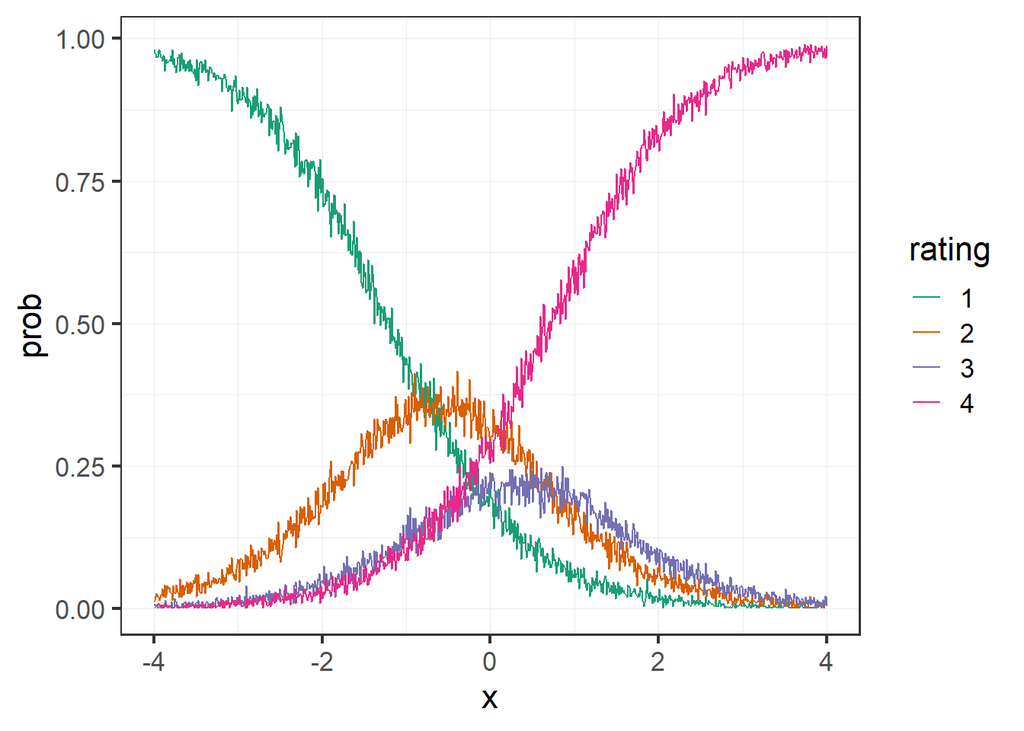

```r
# Helper to categorize values of Y* to get ratings Y
ystar_to_y <- function(ystar, thresholds = simulated_mdl$Theta[1,]) {
  indices <- seq_along(thresholds)
  max_val <- length(thresholds)+1L
  vapply(ystar, \(y) {
    for (i in indices) {
      if (y < thresholds[i])
        return (i)
    }
    max_val
  }, 1L)
}

# Sample Y* values at values of x given the model's estimated coefficient
sample_ystar <- function(x, n_ratings = n_points, model = simulated_mdl){
  b <- model$coefficients['x']

  rlogis(n_ratings, location = b*x) # Not negated here
}

# Helper to sample multiple ratings for a given value of x
sample_rating_from_model <- function(x, n_ratings = n_points, model = simulated_mdl){
  ystar_values <- sample_ystar(x, n_ratings, model)

  ystar_to_y(ystar_values)
}

# Sample Y* values and plot
set.seed(111)
sample_data <-
  data.frame(x = rep(xvals, each = n_points),
             rating = c(lapply(xvals,sample_rating_from_model),recursive=TRUE))

sample_data |>
  mutate(rating = ordered(rating)) |>
  group_by(x, rating) |>
  summarize(response_count = n(),
            prob = response_count / n_points) |>
  ggplot(aes(x = x, y = prob, color = rating, group = rating)) +
  geom_line() +
  plot_theme
```

Compare this to the empirical data we plotted at the beginning. It looks the same! We sampled values in 2 different ways: once through multinomial sampling of discrete values of $Y$ given fixed response probabilities (derived from fixed thresholds) and values of x, and once through sampling continuous values of $Y*$ from a logistic distribution then categorizing the sampled results to get discrete ratings (following a latent variable motivation for the CLM).

We can also look at the distribution of $Y*$ values at a few values of `x`. Plotted are the probability density curves scaled to the number of sampled points and a histogram of $Y*$ values with the thresholds shown in red.

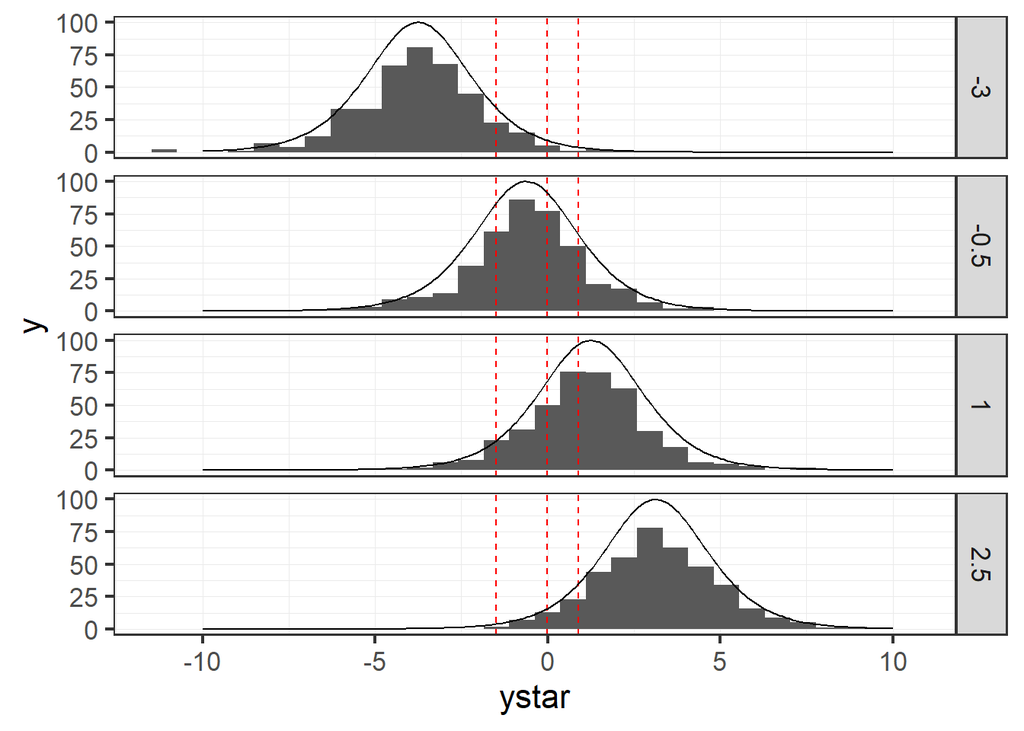

```r
set.seed(111)
test_x_vals <- c(-3, -.5, 1, 2.5)
ystar_dist_df <-
  data.frame(x = rep(test_x_vals, each = n_points),
             ystar = c(lapply(test_x_vals,sample_ystar),recursive=TRUE))

beta <- simulated_mdl$coefficients['x']
locations <- summarize(ystar_dist_df,
          .by = 'x') |>
  mutate(beta_x = beta * x)

ystar_dist_df |>
  ggplot(aes(x = ystar)) +
  geom_histogram() +
  plot_thetas(FALSE) +
  lapply(test_x_vals,
         \(l)
         geom_line(data=data.frame(xvals = seq(-10,10,.1),
                              x = l,
                              y = dlogis(seq(-10,10,.1),location = beta*l)*n_points),
                   aes(x = xvals, y = y, group = x)))+
  facet_grid(x~.) +
  plot_theme
```

## Conclusions

Here are the take homes based on the simulations. First, the thresholds $\theta_j$ shows how the values of $Y*$ are categorized into discrete rating categories $Y$. In other words, the distribution of $Y*$ is partitioned by the thresholds. However, the $Y*$ values are distributed about a location parameter that depends on `x`, for our simple model this is just $\beta x$. The threshold values can be scaled by $\beta$ to identify the values of `x` at which different cumulative probabilities are equal to 50%. But these values do not necessarily correspond to the points at which the predicted ratings $Y$ change. This is because the individual probability of one response category may be less likely than the *sum* of the individual probabilities of each higher rating while still being the most likely *individual* response category. We can nonetheless recover the estimated proportions of each rating category by sampling from the link function’s distribution conditioned on a value of `x`.

So, values of $Y*$ increase in categorized value $Y$ when surpassing a threshold. If we use a continuous predictor, then we should be able to identify a region at which we pass from one rating to another. But, we noted that there was no region at which we got 3s. This arises because `x` is related to the distribution of $Y*$ values, but the predicted value $Y$ depends on considering the allocation of probability given all of the thresholds and choosing the value with the highest probability, which is not guaranteed to be an infrequent response category.